# Practica general

María Llorente Remartínez

18/1/2022

link html en GitHub https://github.com/mariallorente/Practica-general-Curso-R.git

Son datos de 344 pingüinos de tres especies distintas donde la base “penguins” contiene información de la isla, la longitud y profundidad del pico (mm), longitud de la aleta, tamaño, sexo.

Cargo la librería y los datos. Veo la estructura de la tabla y calculos los datos pedidos:

```r
library(palmerpenguins)
data(package = 'palmerpenguins')
library(ggplot2)
```

```r
View(penguins)
str(penguins)
```

```
## tibble [344 x 8] (S3: tbl_df/tbl/data.frame)
##  $ species          : Factor w/ 3 levels "Adelie","Chinstrap",..: 1 1 1 1 1 1 1 1 1 1 ...
##  $ island           : Factor w/ 3 levels "Biscoe","Dream",..: 3 3 3 3 3 3 3 3 3 3 ...
##  $ bill_length_mm   : num [1:344] 39.1 39.5 40.3 NA 36.7 39.3 38.9 39.2 34.1 42 ...
##  $ bill_depth_mm    : num [1:344] 18.7 17.4 18 NA 19.3 20.6 17.8 19.6 18.1 20.2 ...
##  $ flipper_length_mm: int [1:344] 181 186 195 NA 193 190 181 195 193 190 ...
##  $ body_mass_g      : int [1:344] 3750 3800 3250 NA 3450 3650 3625 4675 3475 4250 ...
##  $ sex              : Factor w/ 2 levels "female","male": 2 1 1 NA 1 2 1 2 NA NA ...
##  $ year             : int [1:344] 2007 2007 2007 2007 2007 2007 2007 2007 2007 2007 ...
```

```r
summary(penguins)
```

```
##       species          island    bill_length_mm  bill_depth_mm
##  Adelie   :152   Biscoe   :168   Min.   :32.10   Min.   :13.10
##  Chinstrap: 68   Dream    :124   1st Qu.:39.23   1st Qu.:15.60
##  Gentoo   :124   Torgersen: 52   Median :44.45   Median :17.30
##                                  Mean   :43.92   Mean   :17.15
##                                  3rd Qu.:48.50   3rd Qu.:18.70
##                                  Max.   :59.60   Max.   :21.50
##                                  NA's   :2       NA's   :2
##  flipper_length_mm  body_mass_g       sex           year
##  Min.   :172.0     Min.   :2700   female:165   Min.   :2007
##  1st Qu.:190.0     1st Qu.:3550   male  :168   1st Qu.:2007
##  Median :197.0     Median :4050   NA's  : 11   Median :2008
##  Mean   :200.9     Mean   :4202                Mean   :2008
##  3rd Qu.:213.0     3rd Qu.:4750                3rd Qu.:2009
##  Max.   :231.0     Max.   :6300                Max.   :2009
##  NA's   :2         NA's   :2
```

```r
sd(penguins$bill_length_mm, na.rm = TRUE)
```

```
## [1] 5.459584
```

```r
sd(penguins$bill_depth_mm, na.rm = TRUE)
```

```
## [1] 1.974793
```

```r
sd(penguins$flipper_length_mm, na.rm = TRUE)
```

```
## [1] 14.06171
```

```r
sd(penguins$body_mass_g, na.rm = TRUE)
```

```
## [1] 801.9545
```

1. Número de individuos totales: 344

   Masculinos: 168

   Femeninos: 165

   Especie: Adelie :152

   Chinstrap: 68

   Gentoo :124

Longitud del pico (bill lenght): media: 43.92 mm

desviación estándar: 5.459584

valor min: 32.1 mm

valor máx: 59.6 mm

Profundidad del pico (bill depth): media: 17.15 mm

desviación estándar: 1.974793

valor min: 13.1 mm

valor máx: 21.5 mm

Longitud de la aleta (flipper length): media: 200.9 mm

desviación estándar: 14.06171

valor min: 172.0 mm

valor máx: 231.0 mm

Tamaño (body mass): media: 4202 g

desviación estándar:801.9545

valor min: 2700 g

valor máx: 6300 g

2. Un gráfico de barras que represente el número de individuos muestreados de cada especie en cada isla, representando las especies en diferentes colores (chinstrap – morado, gentoo – azul, adelie – naranja).

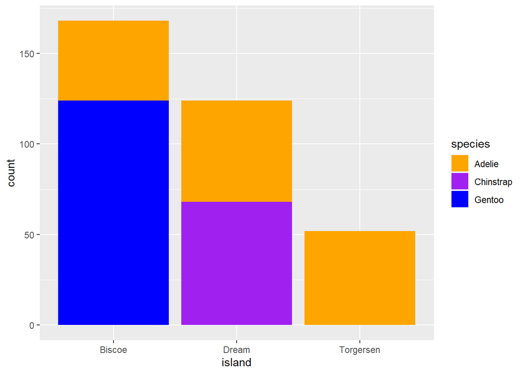

```r
ggplot(data = penguins)+
     geom_bar(aes(x = island, fill = species)) + scale_fill_manual(values= c("orange", "purple", "blue"))
```

Contesta a las siguientes preguntas:

¿Qué especie se ha muestreado en las tres islas? Adelie

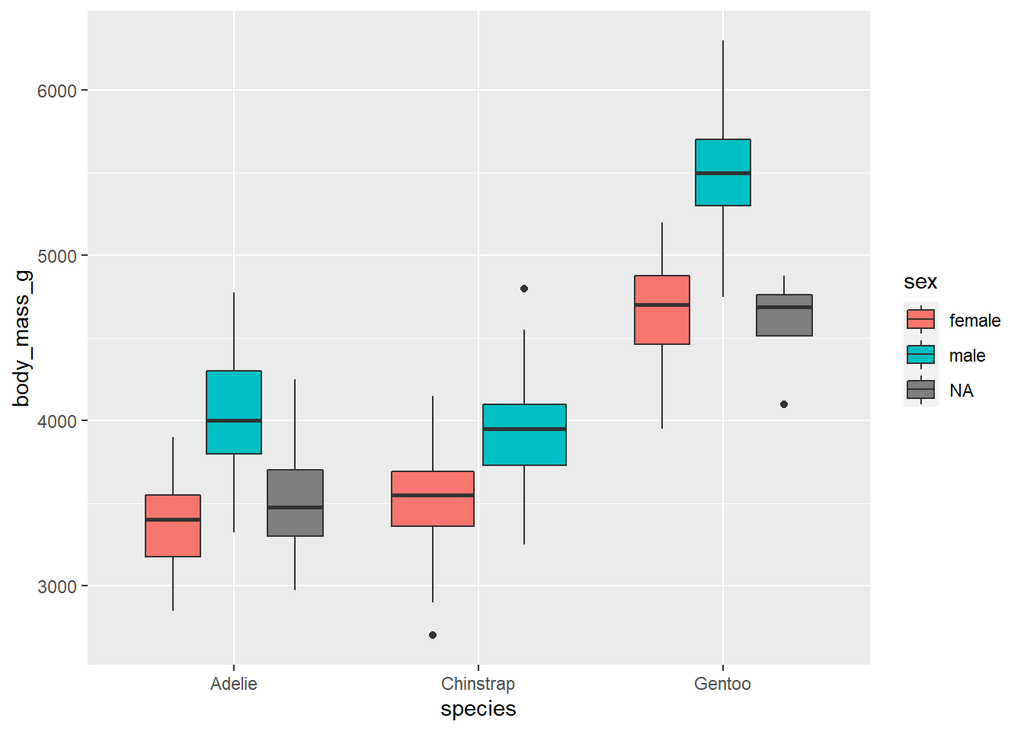

```r
ggplot(data=penguins)+
   geom_boxplot(aes(x= species, y = body_mass_g, fill = sex))
```

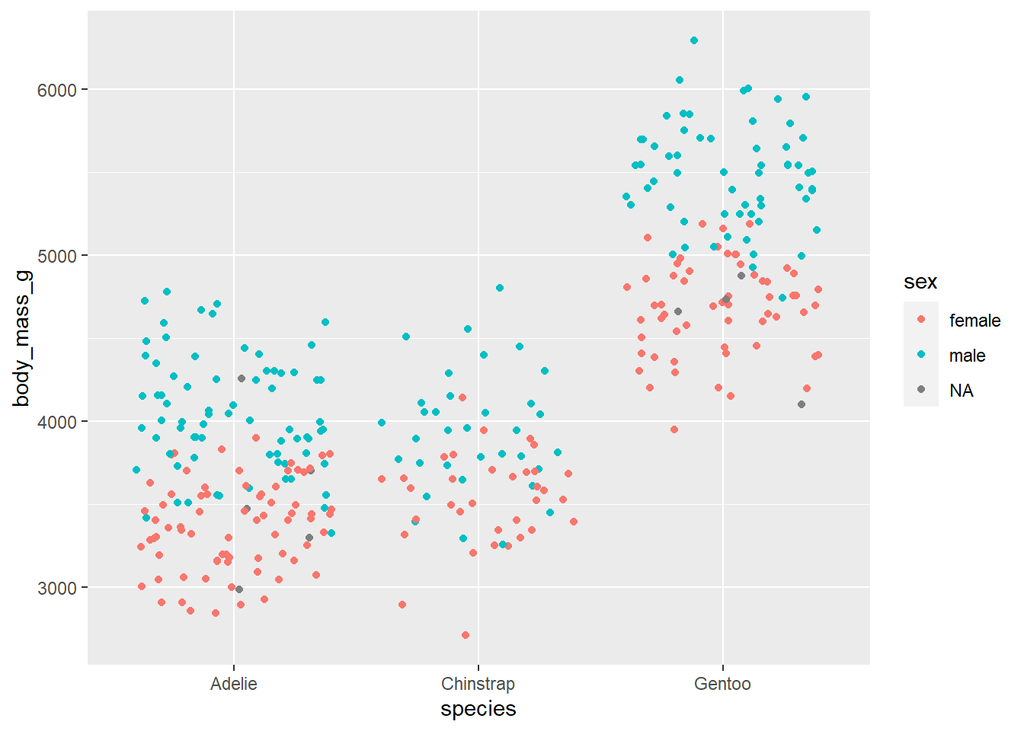

```r
ggplot(data=penguins)+
   geom_jitter(aes(x= species, y = body_mass_g, color = sex))
```

Contesta a las siguientes preguntas: ¿Qué especie tiene mayor tamaño? Gentoo

¿En qué especie las hembras y los machos tienen un tamaño más similar? Chinstrap

```r
citation()
```

```
##
##
##   R Core Team (2021). R: A language and environment for statistical
##   computing. R Foundation for Statistical Computing, Vienna, Austria.
##   URL https://www.R-project.org/.
##
## A BibTeX entry for LaTeX users is
##
##   @Manual{,
##     title = {R: A Language and Environment for Statistical Computing},
##     author = {{R Core Team}},
##     organization = {R Foundation for Statistical Computing},
##     address = {Vienna, Austria},
##     year = {2021},
##     url = {https://www.R-project.org/},
##   }
##
## We have invested a lot of time and effort in creating R, please cite it
## when using it for data analysis. See also 'citation("pkgname")' for
## citing R packages.
```

```r
citation("palmerpenguins")
```

```
##
##
##   Horst AM, Hill AP, Gorman KB (2020). palmerpenguins: Palmer
##   Archipelago (Antarctica) penguin data. R package version 0.1.0.
##   https://allisonhorst.github.io/palmerpenguins/
##
## A BibTeX entry for LaTeX users is
##
##   @Manual{,
##     title = {palmerpenguins: Palmer Archipelago (Antarctica) penguin data},
##     author = {Allison Marie Horst and Alison Presmanes Hill and Kristen B Gorman},
##     year = {2020},
##     note = {R package version 0.1.0},
##     url = {https://allisonhorst.github.io/palmerpenguins/},
##   }
```

```r
citation("ggplot2")
```

```
##
##
##   H. Wickham. ggplot2: Elegant Graphics for Data Analysis.
##   Springer-Verlag New York, 2016.
##
## A BibTeX entry for LaTeX users is
##
##   @Book{,
##     author = {Hadley Wickham},
##     title = {ggplot2: Elegant Graphics for Data Analysis},
##     publisher = {Springer-Verlag New York},
##     year = {2016},
##     isbn = {978-3-319-24277-4},
##     url = {https://ggplot2.tidyverse.org},
##   }
```